# Telling a Story of Diversity in STEM Using Datamined Twitter Data

2021 Technica Hackathon Project

Maria Nikolaitchik and Michal Magidson

11/14/2021

## Introduction

Techinca is the largest east coast hackathon for underrepresented genders in coding. As a first time hacker at Technica, I partnered with a friend to analyze a dataset and see what kind of story we could tell as a project.

## The Data

The focus of our analysis is a data set of webscraped tweets each including hashtags relating to STEM and computer science. The dataset in its raw form includes 81325 rows and 9 columns. However, many of the rows are actually retweets. Filtering out missing data rows and duplcate values we obtain 14987 rows of tweets.

## Time Period

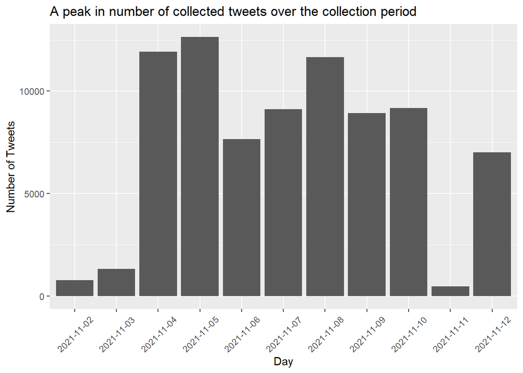

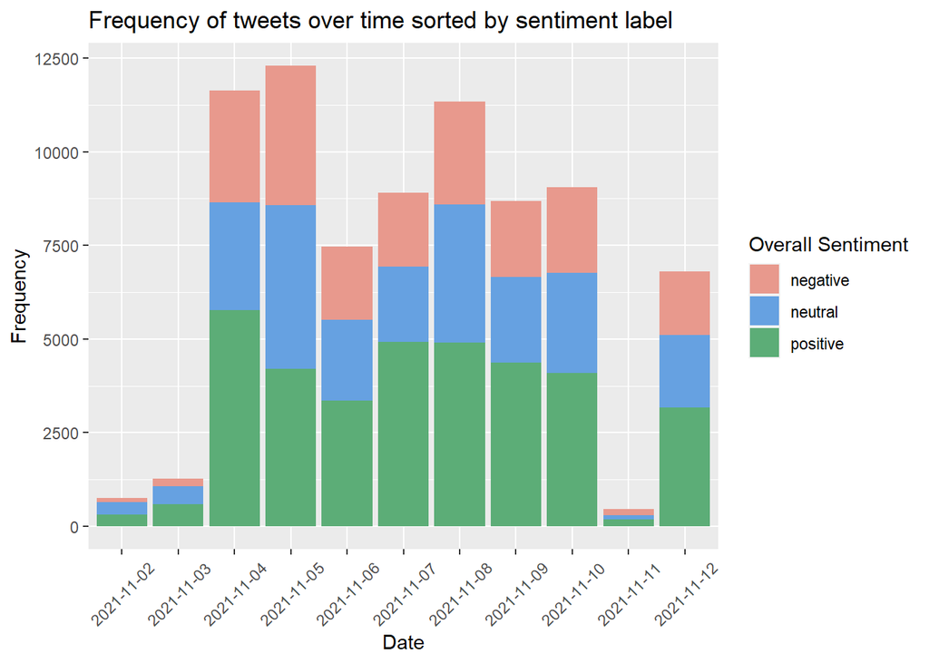

Note that there is an unusually small amount of tweets mined on November 11th. Zooming in further we can see there are no tweets mined from 2:00 to 23:00 on November 11th.

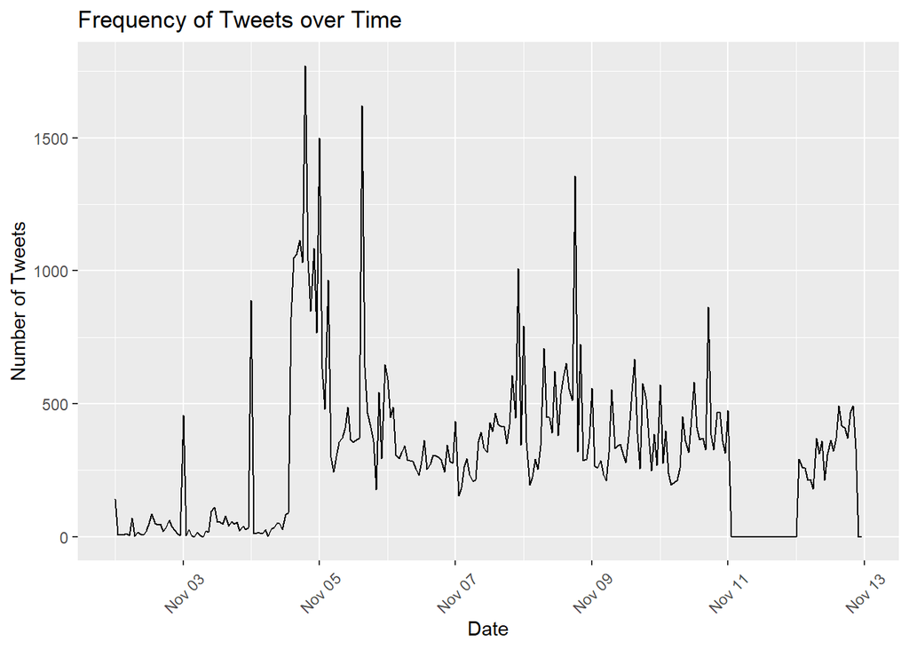

Summarizing tweet length by day, we can see that the data is heavily influenced by outliers as you can see by comparing the median with the mean of each day.

| Date | N | Mean | Median | Max | Min |
| --- | --- | --- | --- | --- | --- |
| 2021-11-02 | 774 | 2210.5375 | 271 | 15120 | 1 |
| 2021-11-03 | 1312 | 2866.3125 | 279 | 30651 | 1 |
| 2021-11-04 | 11912 | 793.3345 | 273 | 28193 | 1 |
| 2021-11-05 | 12432 | 338.1318 | 265 | 26210 | 1 |
| 2021-11-06 | 7646 | 315.1851 | 270 | 11280 | 1 |
| 2021-11-07 | 9111 | 314.4931 | 273 | 32759 | 1 |
| 2021-11-08 | 11496 | 408.5547 | 265 | 13162 | 1 |
| 2021-11-09 | 8912 | 511.9715 | 268 | 18524 | 1 |
| 2021-11-10 | 9164 | 392.6758 | 268 | 15011 | 1 |
| 2021-11-11 | 474 | 935.2025 | 273 | 10260 | 1 |
| 2021-11-12 | 7019 | 254.1883 | 273 | 11143 | 1 |

## Authors

Each tweet is not just a single post from a single account. There were a number of bots in the dataset. Here are the top 15 posters of who tweeted the highest number of distinct tweets.

| Author | N |
| --- | --- |
| womeninstemSA | 860 |
| t.co | 593 |
| B0tSci | 483 |
| BotFemale | 460 |
| AdvanceML | 361 |
| WomenCodersBot | 234 |
| in_stemm | 225 |
| morolswediu | 131 |
| PythonRoboto | 125 |
| steminist_bot | 123 |
| CoderRetweet | 121 |
| BotRaj1 | 120 |
| DjangoBot_ | 115 |
| _EllaBot | 97 |
| BotSecx | 96 |

## Hashtag Distribution

Overall the number of hashtags is skewed heavily towards the smaller end. Here the results are separated based upon the overall result of their sentiment score.

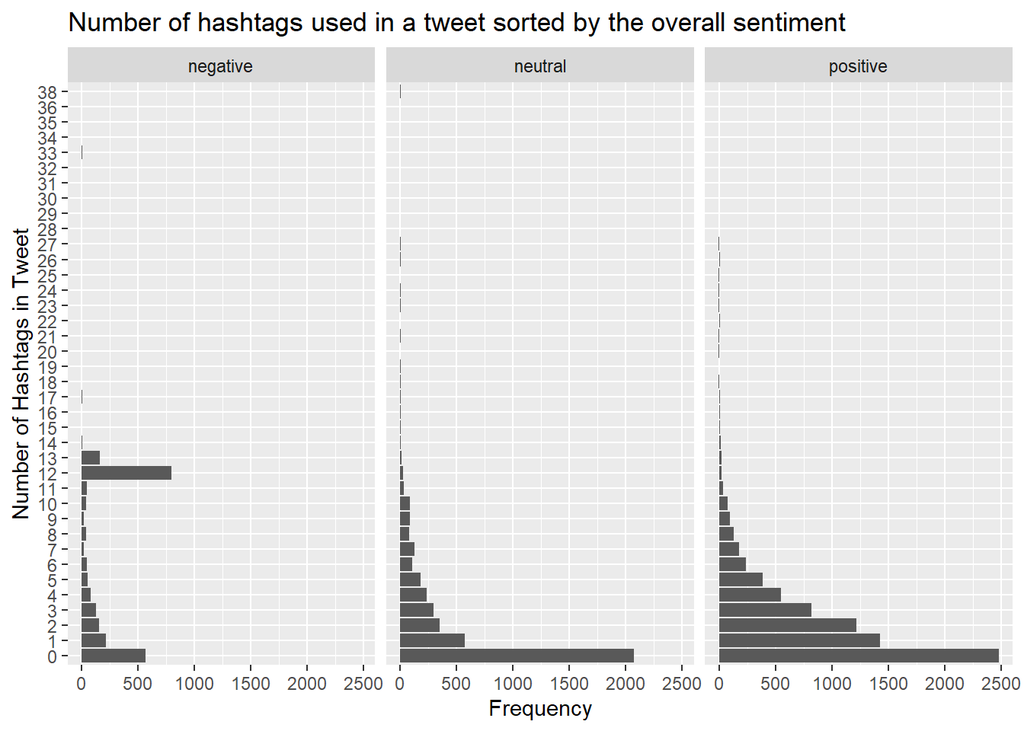

## Hashtags

If we breakdown the analysis of hashtags further. We can find the most often used hashtags of the time period in our dataset. Taking all hashtags recorded over the dataset, we can the top recorded hashtags.

[interactive chart not shown]

However, this is not factoring retweets which may duplicate the hashtags used. This is the word cloud factoring out retweets.

[interactive chart not shown]

If we divide the data into days, we can see consistencies between hashtag popularities over the time period. We can create gifset looping over each wordcloud associates with each day.

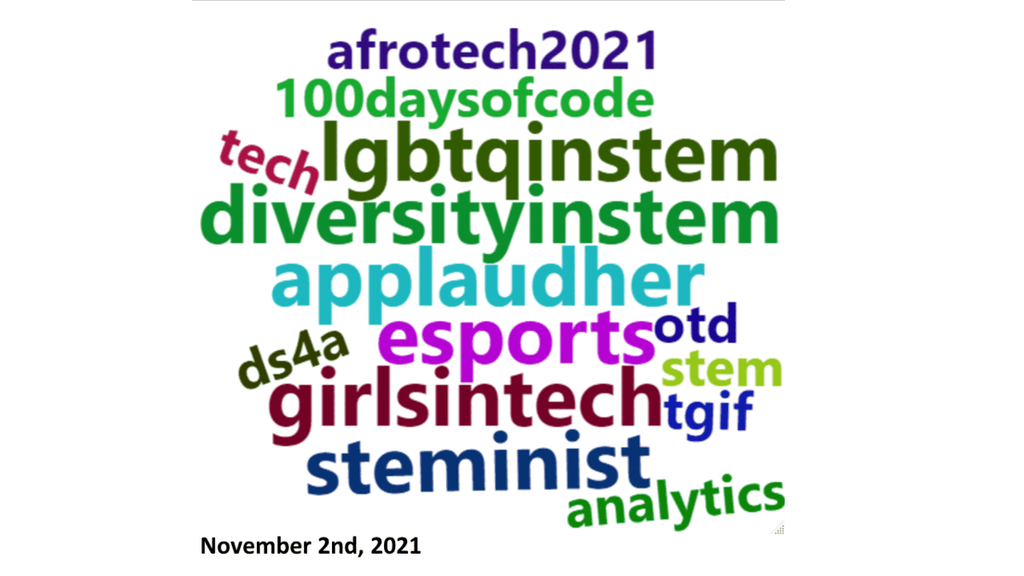

A gif iterating the wordcloud for each day

## Further Research

If given more time, we would explore deeper into the correlation between the hashtags that appear in a tweet and the overall sentiment score of said tweet. We would try to answer the question of, is there a subset of hashtags common in many negative tweets?